# SGG - Who are the main players?

André Soares

8 January 2018

## 1 - General view of taxonomic profiles across the dataset

```r
# agglomerate taxa
ps.b.r.glom <- tax_glom(ps.b.r, taxrank = 'Phylum', NArm = FALSE)
# create dataframe from phyloseq object
ps.b.r.glom.psdf <- data.table(psmelt(ps.b.r.glom))
# convert Phylum to a character vector from a factor because R
ps.b.r.glom.psdf$Phylum <- as.character(ps.b.r.glom.psdf$Phylum)
# group dataframe by Phylum, calculate median rel. abundance
ps.b.r.glom.psdf[, median := median(Abundance, na.rm = TRUE),
                 by = "Phylum"]
# Change name to remainder of Phylum less than 1%
ps.b.r.glom.psdf[(median <= 0.01), Phylum := "Other"]
#Removing Proteobacteria from previous table
ps.b.r.glom.psdf.noProteo<-ps.b.r.glom.psdf[!grepl("Proteobacteria", ps.b.r.glom.psdf$Phylum),]
#New table, with Proteobacterial classes only
ps.b.r.ProtCl = subset_taxa(ps.b.r, Phylum == "Proteobacteria")
ps.b.r.ProtCl.glom <- tax_glom(ps.b.r.ProtCl, taxrank = 'Class', NArm = FALSE)
# create dataframe from phyloseq object
ps.b.r.ProtCl.glom.psdf <- data.table(psmelt(ps.b.r.ProtCl.glom))
# convert Class to a character vector from a factor because R
ps.b.r.ProtCl.glom.psdf$Class <- as.character(ps.b.r.ProtCl.glom.psdf$Class)
# group dataframe by Phylum, calculate median rel. abundance
ps.b.r.ProtCl.glom.psdf[, median := median(Abundance, na.rm = TRUE),
                        by = "Class"]
# Change name to remainder of Phylum less than 1%
ps.b.r.ProtCl.glom.psdf[(median <= 0.01), Class := "Other Proteobacteria"]
ps.b.r.ProtCl.glom.psdf.noP <- subset(ps.b.r.ProtCl.glom.psdf, select = -Phylum)
#same name= allows merging
names(ps.b.r.glom.psdf.noProteo)[names(ps.b.r.glom.psdf.noProteo) == 'Phylum'] <- 'Taxa'
names(ps.b.r.ProtCl.glom.psdf.noP)[names(ps.b.r.ProtCl.glom.psdf.noP) == 'Class'] <- 'Taxa'
#join the two
ps.b.r.ProteoCl.AllPhy <- rbind(ps.b.r.glom.psdf.noProteo, ps.b.r.ProtCl.glom.psdf.noP)

ps.b.r.ProteoCl.AllPhy$Site.name = factor(ps.b.r.ProteoCl.AllPhy$Site.name,
                                                       levels = c("Celynen North","Crumlin Navigation","Six Bells",
                                                                  "Blaenavon","Cefn Hengoed","Dinas","Glyncastle",
                                                                  "Morlais","Mountain Gate","Taff Bargoed","Ynysarwed","Lindsay",
                                                                  "Taffs Well"))

ps.b.r.ProteoCl.AllPhy.plot<-ggplot(ps.b.r.ProteoCl.AllPhy[Abundance > 0],
                                    aes(x = Site.name, y = Abundance/3, fill = Taxa)) +
  facet_grid(Month~.) +
  geom_bar(stat = "identity") +
  theme(axis.title.x = element_blank(),
        axis.text.x = element_text(angle = 45, hjust = 1)) +
  guides(fill = guide_legend(keywidth = 1, keyheight = 1)) +
  ylab("Relative Abundance\n")
#totals vary because the bars = medians
```

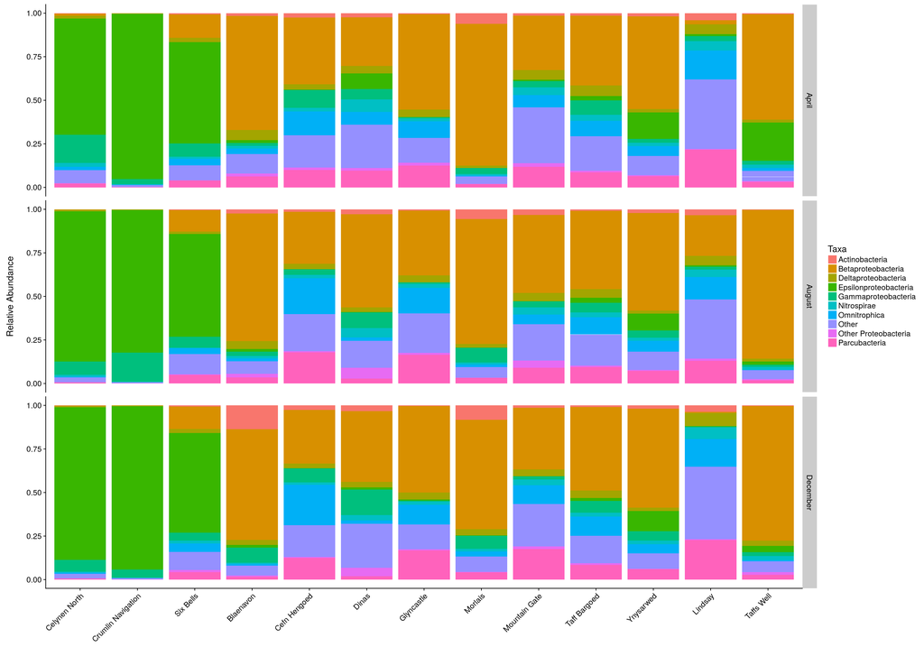

```r
ps.b.r.ProteoCl.AllPhy.plot
```

Clearly, the dataset is mostly populated by Beta- and Epsilonproteobacteria, which seem to correspond to iron- and sulphur-rich sites, respectively. However, certain sites like Lindsay, Cefn Hengoed and Mountain Gate have large percentages of either ‘Other’ less abundant phyla or have ~30-50% of their profiles dominated by Parcubacteria and Omnitrophica.

No obvious temporal trends arise from this, aside from indications that Betaproteobacterial presence decreases across the year in Blaenavon, cefn Hengoed and Morlais. The opposite happens in Taff Bargoed and Taffs Well. The Epsilonproteobacterial dominance in Crumlin Navigation and Celynen North seems to be opposed only be Gammaproteobacteria.